# mtcars Analysis

## Overview

The data from mtcars will be looked at and analyzed to determine the relationship between the miles per gallon and the transmission of the car.

## Exploratory Analysis

The data is first loaded and converted to factors

```r
library(ggplot2)
require(gridExtra)
data(mtcars)

mtcars$am = as.factor(mtcars$am)
mtcars$cyl = as.factor(mtcars$cyl)
mtcars$gear = as.factor(mtcars$gear)
mtcars$car = as.factor(mtcars$carb)
mtcars$vs = as.factor(mtcars$vs)

auto = subset(mtcars, mtcars$am == 0)
man = subset(mtcars, mtcars$am == 1)
```

A quick plot is setup in order to see how the data is distributed amonst transmission and mpg

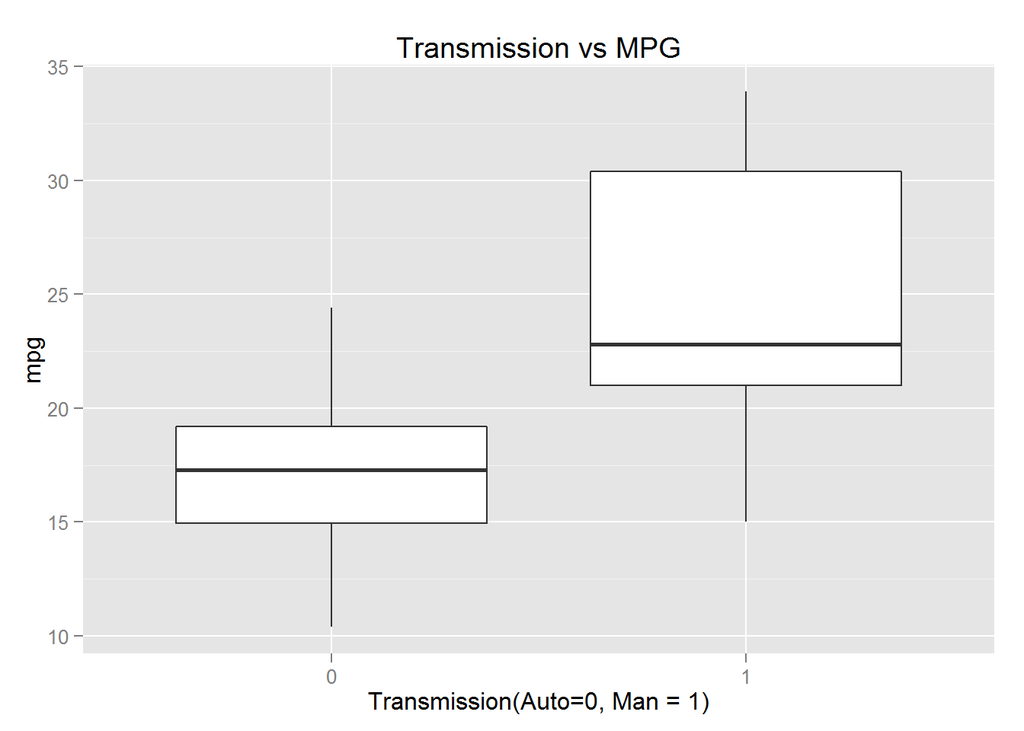

As can be seen in the figure above, manual cars appear to have a higher maximum mpg and minimum mpg. The range in mpg widely varies amongst manual cars compared to automatic.

```r
t.test(man$mpg, auto$mpg)
```

```
##
##  Welch Two Sample t-test
##
## data:  man$mpg and auto$mpg
## t = 3.7671, df = 18.332, p-value = 0.001374
## alternative hypothesis: true difference in means is not equal to 0
## 95 percent confidence interval:
##   3.209684 11.280194
## sample estimates:
## mean of x mean of y
##  24.39231  17.14737
```

In addition, as can be seen in the two item T test of both the manual and automatic transmissions, there is a 95% confidence interval of 3.21-11.28 showing that there is likely to be some difference between manual and automatic transmissions. The p value is low enough to reject the notion that there is no difference between mpg amongst transmissions and that manual is better for mpg than automatic. In addition, the difference in the means can be easily seen with manual have an average mpg of 24.39 and automatic have an anverage of 17.1